# Logística e a Jornada de Satisfação do Cliente

Análise Estratégica de Churn e Performance de Entrega no E-commerce

Autor

Gabriel Leonardo Fadul

Data de Publicação

5 de abril de 2026

# 1 Introdução e Objetivos

Este relatório apresenta uma análise detalhada da base de dados pública da **Olist**, o maior ecossistema de *e-commerce* do Brasil. O objetivo central deste estudo é mapear a eficiência logística e investigar como o desempenho das entregas atua como um determinante direto na retenção e na satisfação do consumidor final. Em um país com dimensões continentais e desafios complexos, a logística deixa de ser apenas um suporte operacional para se tornar o principal motor de experiência do cliente.

A investigação inicia-se pela análise da “dor do cliente”, buscando quantificar o impacto dos atrasos logísticos na satisfação do consumidor. Nesse contexto, explorou-se o comportamento de engajamento dos usuários através de três pilares: os comentários nas avaliações, o status de entrega e atrasos e as avaliações gerais.

Adicionalmente, o estudo aprofunda-se nas disparidades geográficas brasileiras, analisando como a localização do consumidor e a proporção do custo do frete no valor total do pedido influenciam a percepção de valor e a viabilidade da compra.

Por fim, utilizando metodologias de análise exploratória e modelagem estatística, este trabalho foca na recorrência e no risco de *churn*. O intuito é compreender o intervalo entre compras e o peso que uma experiência de entrega positiva exerce na probabilidade de fidelização.

# 2 Preparação de Dados

A base de dados utilizada neste projeto é proveniente do ecossistema público da **Olist**, disponível via Kaggle. Para garantir a integridade das análises estatísticas, toda a etapa de ETL e tratamento de dados foi desenvolvida em linguagem **R**, utilizando o ecossistema *Tidyverse* (principalmente os pacotes `dplyr`, `tidyr` e `vroom` para leitura eficiente de grandes volumes).

## 2.1 Agrupamento de Itens

Durante a fase de exploração, foi identificado uma característica estrutural que poderia enviesar significativamente os resultados de satisfação e logística: a base original estava segmentada por item de pedido, e não por pedido único.

Isso significa que, se um cliente comprasse cinco itens em uma única transação (“carrinho”), o banco de dados gerava cinco linhas distintas. Como os indicadores de atraso, nota de avaliação e comentários são atribuídos ao pedido como um todo, o cálculo geraria um viés, superestimando o peso de pedidos com múltiplos itens.

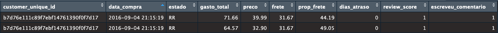

Figura 1: Exemplo de redundância estrutural onde um único pedido gera múltiplas entradas, duplicando métricas de satisfação e atraso.

Para mitigar esse viés, os dados foram agrupados por ID único de cliente e data de compra, consolidando os valores financeiros e mantendo a unicidade dos indicadores qualitativos.

Esta metodologia permitiu que cada experiência de compra fosse contabilizada como uma unidade estatística única, garantindo que as análise reflitam a realidade da jornada do consumidor, independentemente da quantidade de produtos adquiridos em uma mesma transação.

# 3 Análise de Atrasos e Avaliações

Nesta seção, exploramos a distribuição do tempo de entrega e como o consumidor reage a quebras de expectativa logística. Utilizamos abas para separar a visão da logística operacional e a reação do consumidor.

**📦 Logística: Volume e Atrasos**

A maior parte da operação da Olist flui de forma adiantada, demonstrando folga nas estimativas de frete. Contudo, quando a falha ocorre, a distribuição dos dias de atraso se revela severa e com forte assimetria à direita.

[figure not shown]

**⭐ Satisfação e Quebra de Expectativa**

Ao cruzar a variável de atrasos com o *Review Score*, o impacto fica cristalino. O Ridgeline Plot abaixo prova visualmente que notas altas toleram pouquíssimo tempo de atraso, enquanto as avaliações com nota 1 se arrastam pela cauda longa.

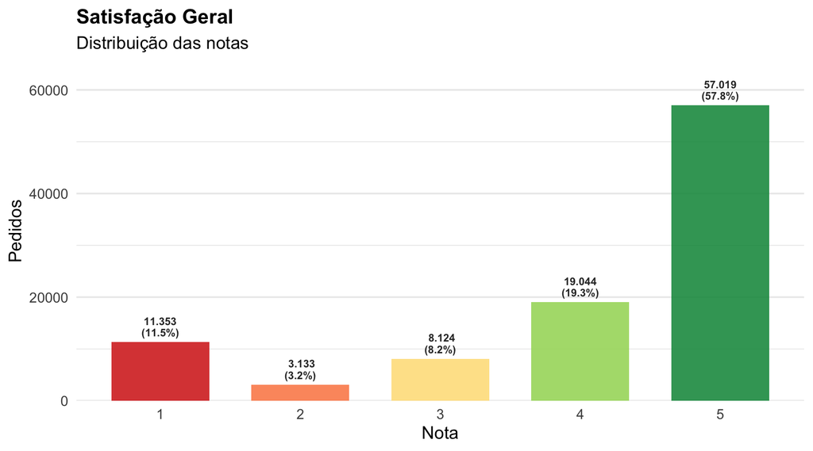

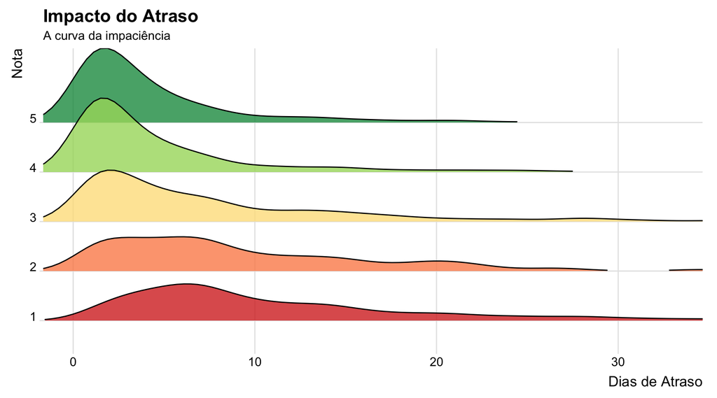

> **Rigor Estatístico:** Para quantificar este fenômeno, aplicou-se a **Correlação de Rank de Spearman**. Como a avaliação é uma variável ordinal discreta, utilizou-se o coeficiente $\rho$ (rho). O teste revelou uma correlação negativa ($p < 0.001$) de **-0.40**, um tamanho de efeito moderado-forte para comportamento humano, cravando o atraso como o principal ofensor do NPS.

**🗣️ A Curva do Engajamento**

As métricas absolutas mostraram que a nota 5 é a mais comum. Porém, quando analisamos o **comportamento de justificar o voto**, a história muda. Formata-se a clássica “Curva em U”: o ódio engaja muito mais que a satisfação, tornando os comentários de notas baixas minas de ouro para algoritmos de NLP (Processamento de Linguagem Natural).

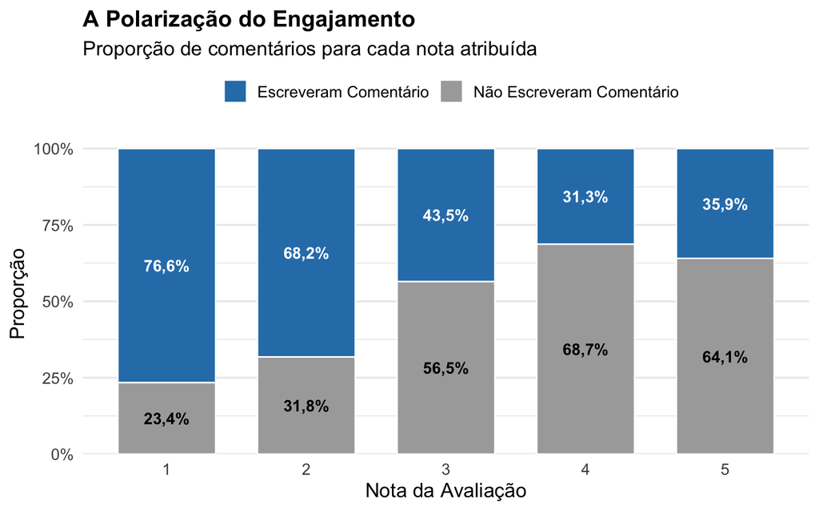